# Han_02

Wanting Han

September 21, 2016

#### 1a. Say “Vole vasopressin” 10 times as fast as you can. How many times did you trip up?

- Once.

#### 1b. What is the mean, median, sd, and interquartile range of the sample?

```r
library(magrittr)
library(dplyr)
vole_vaso <- c(98,96,94,88,86,82,77,74,70,60,59,52,50,47,40,35,29,13,6,5)
vole_mean <- mean(vole_vaso)
vole_median <- median(vole_vaso)
vole_sd <- sd(vole_vaso)
vole_IQR <- IQR(vole_vaso)
```

```r
vole_mean
```

```
## [1] 58.05
```

```r
vole_median
```

```
## [1] 59.5
```

```r
vole_sd
```

```
## [1] 29.75244
```

```r
vole_IQR
```

```
## [1] 44.25
```

#### 1c. What is the standard error of the mean (do this with a formula!)?

```r
vole_n <- vole_vaso %>% length %>% sqrt
vole_se <- vole_sd/vole_n
vole_se
```

```
## [1] 6.652849
```

#### 1d. What does the standard error of the mean tell you about our estimate of the mean values of the population of vole vassopressin?

- Bigger sample sizes, less standard error of the mean, which means the sample estimation is closer to the population.

#### 2a. Use sample() to get just one resample with a sample size of 10. What is its upper quartile?

```r
vole_s10 <-
  sample(vole_vaso, size = 10, replace = TRUE)
quantile(vole_s10, probs = 0.75)
```

```
##   75%
## 70.25
```

### 2b. Build an initial data frame for simulations with the sample sizes 5 through 20. Have 100 simulations per sample size.

```r
vole_df <-
  data.frame(samp_size = rep(5:20, times = 100))
vole_df$sim <- 1:nrow(vole_df)
vole_df
```

```
##      samp_size  sim
## 1            5    1
## 2            6    2
## 3            7    3
## 4            8    4
## 5            9    5
## 6           10    6
## 7           11    7
## 8           12    8
## 9           13    9
## 10          14   10
## 11          15   11
## 12          16   12
## 13          17   13
## 14          18   14
```

[output cut: 1586 more lines]

#### 2c. Use this data frame to get simulated upper quartiles for each sample size.

```r
vole_df_Q <-
  vole_df %>%
  group_by(sim) %>%
  mutate(quantile = quantile(sample(vole_vaso, samp_size, replace = TRUE), probs = 0.75)) %>% ungroup()
vole_df_Q
```

```
## # A tibble: 1,600 × 3
##    samp_size   sim quantile
##        <int> <int>    <dbl>
## 1          5     1    74.00
## 2          6     2    57.50
## 3          7     3    46.00
## 4          8     4    83.50
## 5          9     5    86.00
## 6         10     6    76.50
## 7         11     7    91.00
## 8         12     8    86.00
## 9         13     9    88.00
## 10        14    10    76.25
## # ... with 1,590 more rows
```

### 2d. With a plot, make a guesstimate as to the best sample size for estimating the upper quartile of the population.

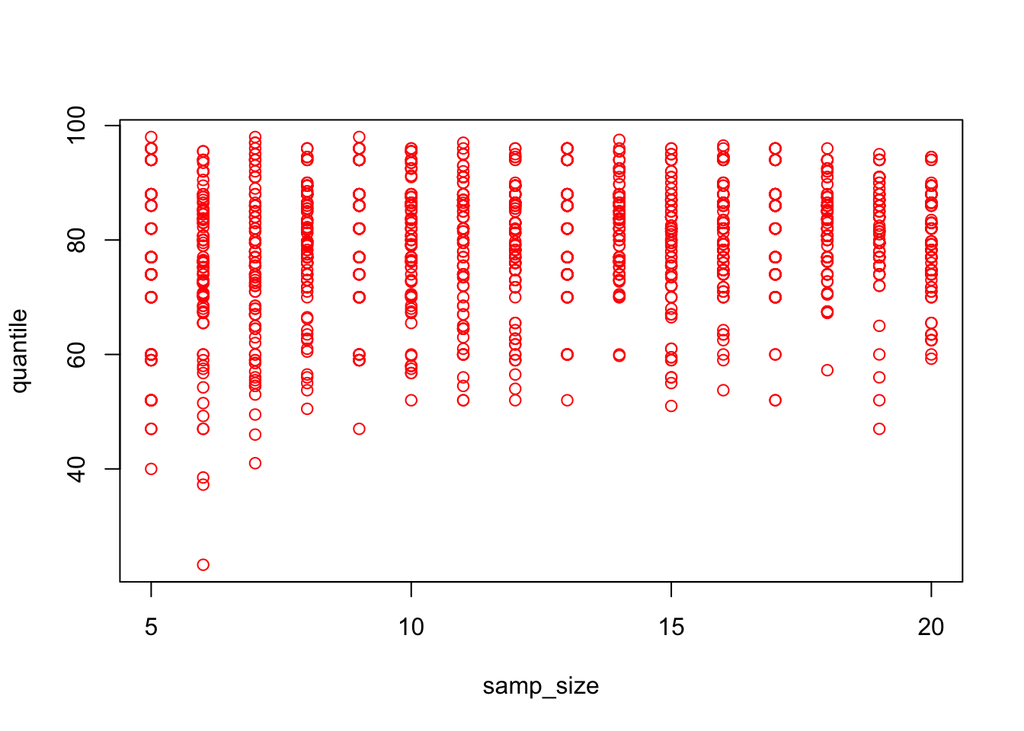

```r
plot(quantile ~ samp_size, data = vole_df_Q, col = "red")
```

### 3a. With the upper quartile simulations, calculate the SD for each sample size using dplyr

```r
vole_df_SD <-
  vole_df_Q %>% group_by(samp_size) %>% summarise(sd = sd(quantile)) %>% ungroup()
vole_df_SD
```

```
## # A tibble: 16 × 2
##    samp_size        sd
##        <int>     <dbl>
## 1          5 14.139346
## 2          6 13.492253
## 3          7 12.814039
## 4          8 10.312668
## 5          9 11.380188
## 6         10 10.463596
## 7         11 11.056525
## 8         12 10.295584
## 9         13 10.050499
## 10        14  7.392395
## 11        15 10.221876
## 12        16  8.731105
## 13        17  9.273815
## 14        18  7.157649
## 15        19  8.401840
## 16        20  8.261606
```

#### 3b. What does this value, the standard error of the upper quartile, mean?

- The standard error of the upper quartile shows how true the estimate of the upper quartile is.

#### 3c. What is the CI of the upper quartile with a sample size of 10. What does this mean?

```r
vole_df_mean <-
  vole_df_Q %>%
  group_by(samp_size) %>%
  summarise(mean = mean(quantile)) %>%
  ungroup()
sd <- filter(vole_df_SD, samp_size == 10)
se <- sd[,2]/sqrt(10)
mean_10 <- vole_df_mean[6, 2]
upper_CI <- mean_10 + 2*se
lower_CI <- mean_10 - 2*se
upper_CI
```

```
##       mean
## 1 86.67276
```

```r
lower_CI
```

```
##       mean
## 1 73.43724
```

- CI tells that there has 95% chance the upper quartile which calculated from sample size of 10 contains the true value of the population.

#### 3d. Extra Credit: Instead of having each sim calculate a upper quartile, and then sifting down to the SE of that upper quartile (or the CI), have each simulation calculate a CI. Then, for just a sample size of 10, how many CI’s contain the true value of 83?

```r
vole_df_mean_sd <-
vole_df %>%
  group_by(sim) %>%
  mutate(mean = mean(sample(vole_vaso, samp_size, replace = TRUE)), sd = sd(sample(vole_vaso, samp_size, replace = TRUE))) %>% ungroup()

vole_df_mean_sd_10 <- filter(vole_df_mean_sd, samp_size == 10)

lower_CI <- vole_df_mean_sd_10[,3]-2*vole_df_mean_sd_10[,4]/sqrt(10)
upper_CI <- vole_df_mean_sd_10[,3]+2*vole_df_mean_sd_10[,4]/sqrt(10)
vole_df_CI <- bind_cols(lower_CI, upper_CI)
names(vole_df_CI) <- c("lower", "upper")

nrow(filter(vole_df_CI, lower<=83, upper>=83))
```

```
## [1] 22
```